# CS4260: Analysis of single-cell transcriptomics of chronic myeloid leukemia

Akash, Hielke, Marthe, Matt

# 1 Supervised learning on responder status (Hielke)

Here, we applied numerous methods to see what supervised learning method would be best to distinguish between different responder statuses.

## 1.1 Set-up

Loading in the packages.

```r
# Data wrangling
library(tidyverse)  # collection of packages a.o: ggplot2, tibble, dplyr
library(magrittr)  # piping
library(reshape2)
library(janitor)  # data cleaning

# Plotting
library(ggplot2)
# library(gridExtra)
library(cowplot)  # grid plotting

# Machine learning
library(MASS)  # LDA, QDA
library(randomForest)
library(glmnet)  # elasticnet, LASSO, Ridge
library(e1071)  # SVM

# Other
library(readxl)  # Read in data from Excel
library(glue)  # String formatting
```

We consider reproducible science to be important.

```r
set.seed(46692)
```

Data loading.

```r
# Get gene expression data (preprocessed)
gene_data <- readxl::read_excel("/home/hielke/repos/mlbio/correctedGeneDataSDMR.xlsx")
gene_data <- column_to_rownames(gene_data, var = "-0.99280765125085602")  # Yeah, this is weird.

# Get meta data_
meta <- read.csv("/home/hielke/repos/mlbio/Metadata.txt", sep="\t")
meta <- column_to_rownames(meta, var = "Cell")
```

## 1.2 Data wrangling and cleaning

Reform data and cleaning.

```r
rownames(gene_data) %<>% make_clean_names(case = "none")
genes <- rownames(gene_data)
gene_data_t <- as_tibble(t(gene_data))
```

Sort the two dataframes so that they can be compared. (The index is the cell id.)

```r
meta <- meta[sort(rownames(meta)), ]
gene_data_t <- gene_data_t[sort(rownames(gene_data_t)),]
```

## 1.3 Create train and test patients

```r
good_pat <- as_vector(unique((dplyr::filter(meta, Responder_status == "good")$Patient_id)))
poor_pat <- as_vector(unique((dplyr::filter(meta, Responder_status == "poor")$Patient_id)))

# Randomness controlled by seed
good_pat_test <- base::sample(good_pat, 2)
poor_pat_test <- base::sample(poor_pat, 2)
pat_test <- fct_c(good_pat_test, poor_pat_test)

good_pat_train <- good_pat[!grepl(paste(pat_test, collapse="|"), good_pat)]
poor_pat_train <- poor_pat[!grepl(paste(pat_test, collapse="|"), poor_pat)]
pat_train <- fct_c(good_pat_train, poor_pat_train)

# This can be done since the frames are sorted on index.
gene_data_t$Patient_id <- meta$Patient_id
gene_data_t$Responder_status <- meta$Responder_status

# Remove "unknown" status (EDIT: Unexplainable bugs came from this.)
# meta_prog <- dplyr::filter(meta, Responder_status %in% c("good", "poor"))
# meta_prog$Responder_status %<>% factor

# gene_data_prog <- gene_data_t %>% filter(Responder_status %in% c("good", "poor"))
# gene_data_prog$Responder_status %<>% factor

# Create test/train set
gene_data_train <- gene_data_t %>% filter(Patient_id %in% pat_train)
gene_data_train$Responder_status %<>% factor
gene_data_test <- gene_data_t %>% filter(Patient_id %in% pat_test)
gene_data_test$Responder_status %<>% factor
```

## 1.4 Utilities

Here a collection of utilities is made that can be used with multiple supervised learning methods.

Create the formula that makes the link between all genes and the Reponder_status.

```r
Responder_to_allgenes <- formula(paste("Responder_status~", paste(sprintf("`%s`", genes), collapse = "+")))
```

A function that summarizes the correctly classified cells.

**NB:** We are using tidyval here. So `predicted_labels` cannot be a string, but instead will be turned into a quosure upon evaluating the arguments. [Here](https://cran.r-project.org/web/packages/dplyr/vignettes/programming.html) for more about that.

```r
select_correct <- function(gene_data, predicted_labels) {
  gene_data %>%
    group_by(Patient_id) %>%
    mutate(cells=n(), correct=sum(Responder_status == !! enquo(predicted_labels))) %>%
    summarise_all(first) %>%
    # dplyr::select(!(one_of(genes))) %>%
    dplyr::select(one_of("Patient_id", "Responder_status", "cells", "correct"))
}
```

A function that can visualize the correctly annoted cells versus the wrongly annotated cells.

```r
visualize_classes <- function(correct_classified, title) {

  # MANGLE

  correct_classified %<>% mutate(incorrect = cells - correct)

  split_correct_incorrect <- function(df, filter) {
    df %>%
      filter(Responder_status == filter) %>%
      dplyr::select(one_of("Patient_id", "correct", "incorrect")) %>%
      melt(id_vars="Patient_id")
  }

  correct_classified_good <- split_correct_incorrect(correct_classified, "good")
  correct_classified_poor <- split_correct_incorrect(correct_classified, "poor")


  # We have crated a correct and an incorrect column, but in the plot
  # we want to visualize "poor" and "good".
  # For _poor the order is already c("correct", "incorrect") ≡ c("poor", "good")
  # But for _good we have to swap that.
  correct_classified_good$variable %<>% factor(c("incorrect", "correct"))

  # PLOT

  ylim_cells <- round(1.1 * max(c(correct_classified_good$value, correct_classified_poor$value)))

  # We are creating two plots and put them next to each other.
  # They share these layers.
  class_barplot_layers <- list(
    aes(x = Patient_id, y = value, group = variable, fill = variable),
    geom_col(position = "dodge"),
    labs(fill = "Classification"),
    xlab("Patient ID"),
    ylab("Amount of cells"),
    scale_fill_manual(values = c("red", "blue"), labels = c("poor", "good")),
    theme(legend.position = "none"),
    ylim(0, ylim_cells),
    theme(axis.text.x = element_text(angle = 90, hjust = 1))
  )

  # Here we create the elements, two plots, and a legend.
  g_good <- ggplot(correct_classified_good) +
    labs(title = "Outcome: good") +
    class_barplot_layers


  g_poor <- ggplot(correct_classified_poor) +
    labs(title = "Outcome: poor") +
    class_barplot_layers

  legend <- get_legend(
    g_poor + theme(legend.position = "right")
  )

  title <- ggdraw() + draw_label(title, fontface = "bold", x = 0, hjust = 0) +
    theme(plot.margin = ggplot2::margin(0, 0, 0, 7))

  plot_body <- plot_grid(g_good, g_poor, legend, align = "h", ncol = 3)

  plot_grid(title, plot_body, ncol = 1, rel_heights = c(.1, 1))
}
```

## 1.5 Different supervised learning methods

### 1.5.1 LDA

Use LDA to find the relationship that relates Responder_status to gene expression.

```r
gene_data_lda <- lda(Responder_to_allgenes, data = gene_data_train, CV = FALSE)
```

#### 1.5.1.1 Verify

Work on train set

```r
gene_data_train$Responder_status_lda <- predict(gene_data_lda)$class
```

```r
correct_classified_train_lda <- select_correct(gene_data_train, Responder_status_lda)
correct_classified_train_lda
```

| Patient_id | Responder_status | cells | correct |
| --- | --- | --- | --- |
| CML1266 | poor | 154 | 134 |
| CML15 | good | 57 | 56 |
| CML22 | good | 55 | 51 |
| CML655 | good | 68 | 49 |
| CML656 | good | 105 | 75 |
| CML691 | good | 30 | 24 |
| CML940 | good | 29 | 26 |
| CML960 | good | 25 | 22 |
| OX1071 | poor | 22 | 21 |
| OX1083 | poor | 26 | 19 |

[output cut: 15 more lines]

Work on test set

```r
gene_data_test$Responder_status_lda <- predict(gene_data_lda, newdata = gene_data_test)$class
```

```r
correct_classified_test_lda <- select_correct(gene_data_test, Responder_status_lda)
correct_classified_test_lda
```

| Patient_id | Responder_status | cells | correct |
| --- | --- | --- | --- |
| OX1528 | poor | 30 | 22 |
| OX2125 | poor | 43 | 31 |
| OX664 | good | 43 | 13 |
| OX967 | good | 58 | 24 |

##### 1.5.1.1.1 Visualize

###### 1.5.1.1.1.1 Train set

It is expected that the train set would perform reasonably well here.

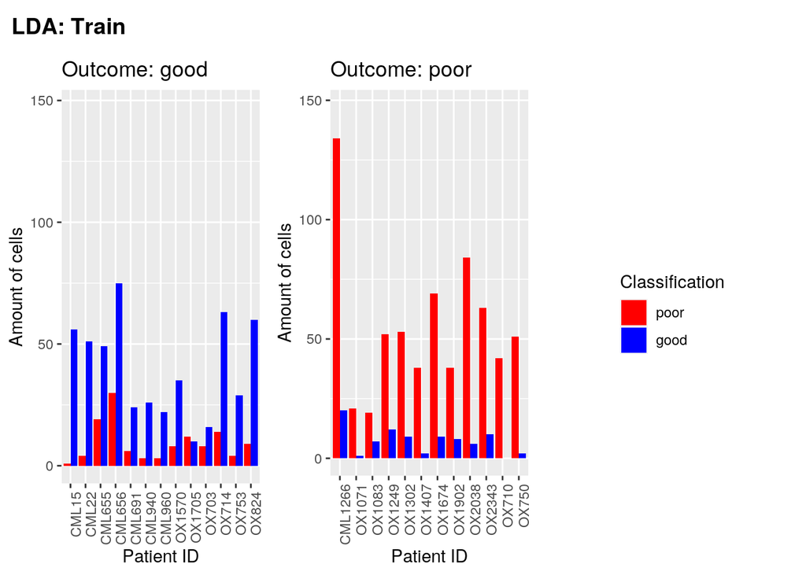

```r
visualize_classes(correct_classified_train_lda, "LDA: Train")
```

###### 1.5.1.1.1.2 Test set

Here we can see how the LDA actually performs, and it does that very poorly.

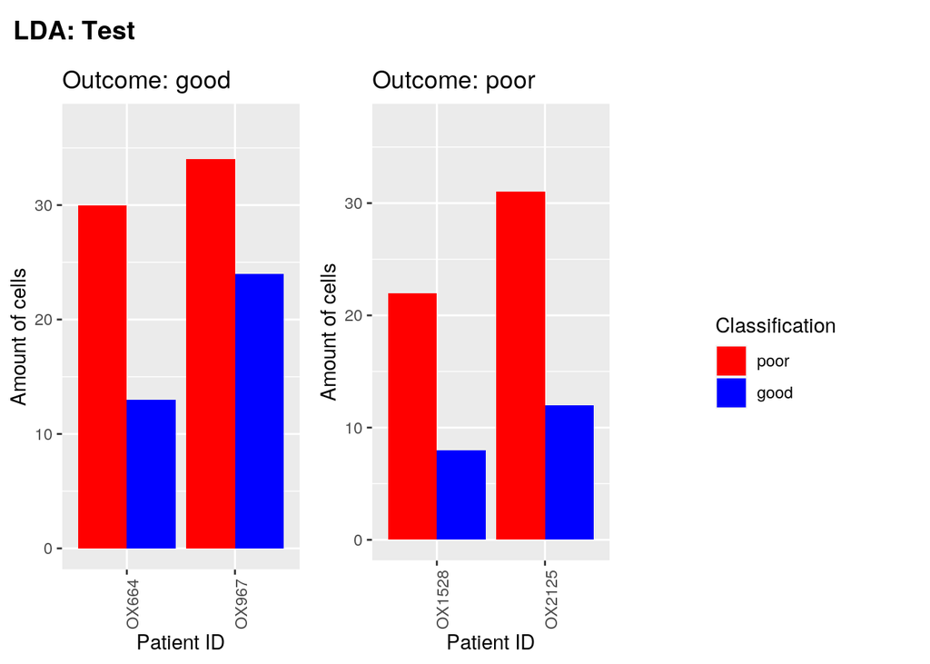

```r
visualize_classes(correct_classified_test_lda, "LDA: Test")
```

### 1.5.2 Random forest

```r
gene_data_rf <- randomForest(Responder_to_allgenes, data = gene_data_train)
```

#### 1.5.2.1 Verify

Work on train set

```r
gene_data_train$Responder_status_rf <- predict(gene_data_rf)
```

```r
correct_classified_train_rf <- select_correct(gene_data_train, Responder_status_rf)
correct_classified_train_rf
```

| Patient_id | Responder_status | cells | correct |
| --- | --- | --- | --- |
| CML1266 | poor | 154 | 143 |
| CML15 | good | 57 | 21 |
| CML22 | good | 55 | 55 |
| CML655 | good | 68 | 59 |
| CML656 | good | 105 | 84 |
| CML691 | good | 30 | 15 |
| CML940 | good | 29 | 29 |
| CML960 | good | 25 | 25 |
| OX1071 | poor | 22 | 11 |
| OX1083 | poor | 26 | 25 |

[output cut: 15 more lines]

Work on test set

```r
gene_data_test$Responder_status_rf <- predict(gene_data_rf, newdata = gene_data_test)
```

```r
correct_classified_test_rf <- select_correct(gene_data_test, Responder_status_rf)
correct_classified_test_rf
```

| Patient_id | Responder_status | cells | correct |
| --- | --- | --- | --- |
| OX1528 | poor | 30 | 13 |
| OX2125 | poor | 43 | 8 |
| OX664 | good | 43 | 11 |
| OX967 | good | 58 | 23 |

##### 1.5.2.1.1 Visualize

###### 1.5.2.1.1.1 Train set

It is expected that the train set would perform reasonably well here. However, it seems that for not all patients it makes the true predictions.

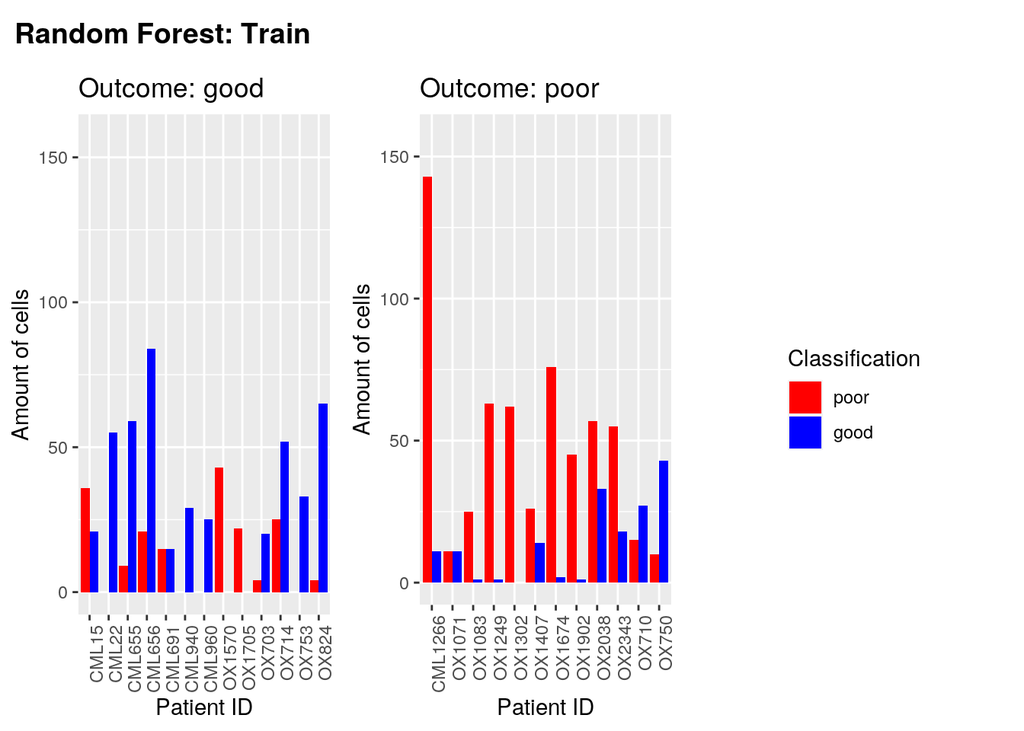

```r
visualize_classes(correct_classified_train_rf, "Random Forest: Train")
```

###### 1.5.2.1.1.2 Test set

Here we can see how the Random Forest actually performs, and here it doesn’t show anything good either.

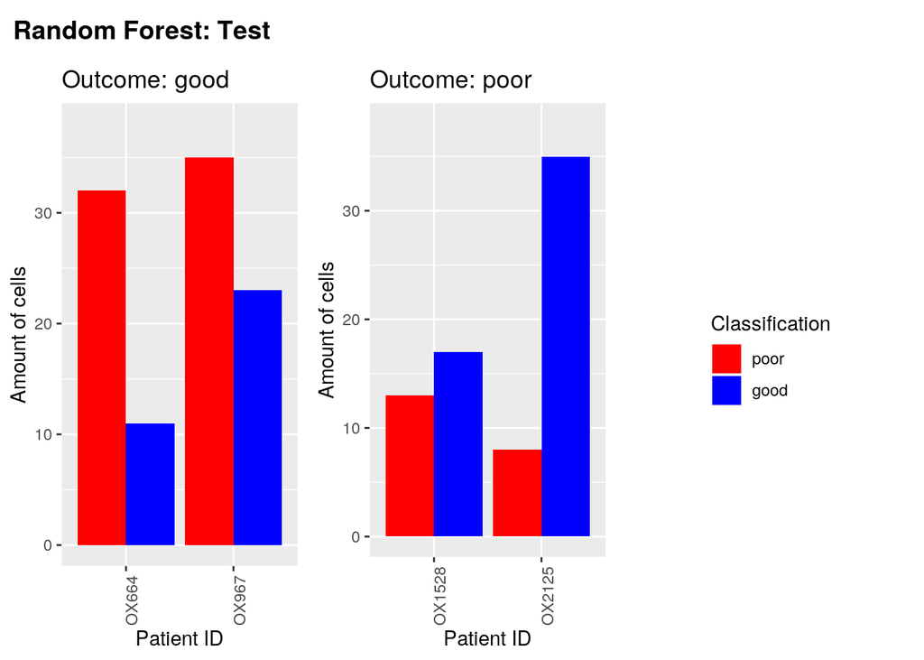

```r
visualize_classes(correct_classified_test_rf, "Random Forest: Test")
```

### 1.5.3 Intermezzo: Most important genes

The Random Forest does bring something extra to the table and that is that it can give a measure to how importance certain variables are. We can use this to make a stricter subset.

```r
size_important_genes <- 500
important_genes <- (
  importance(gene_data_rf) %>%
    as_tibble(rownames = NA) %>%
    rownames_to_column("gene") %>%
    dplyr::arrange(MeanDecreaseGini) %>%
    top_n(size_important_genes)
)$gene
```

Now we can create another formula for that new relationship

```r
Responder_to_mostimportantgenes <- formula(
  paste("Responder_status~", paste(sprintf("`%s`", important_genes), collapse = "+"))
)
```

### 1.5.4 LDA with less genes

Now we can attempt to redo the LDA with less genes and see if we improve. We might be able to improve as we were doing pretty well on the train set, but not that well on the test, indicating we are overfitting a little bit.

```r
gene_data_ldamore <- lda(Responder_to_mostimportantgenes, data = gene_data_train, CV = FALSE)
```

#### 1.5.4.1 Verify

Work on train set

```r
gene_data_train$Responder_status_ldamore <- predict(gene_data_ldamore)$class
```

```r
correct_classified_train_ldamore <- select_correct(gene_data_train, Responder_status_ldamore)
correct_classified_train_ldamore
```

| Patient_id | Responder_status | cells | correct |
| --- | --- | --- | --- |
| CML1266 | poor | 154 | 136 |
| CML15 | good | 57 | 49 |
| CML22 | good | 55 | 50 |
| CML655 | good | 68 | 56 |
| CML656 | good | 105 | 92 |
| CML691 | good | 30 | 24 |
| CML940 | good | 29 | 26 |
| CML960 | good | 25 | 24 |
| OX1071 | poor | 22 | 21 |
| OX1083 | poor | 26 | 24 |

[output cut: 15 more lines]

Work on test set

```r
gene_data_test$Responder_status_ldamore <- predict(gene_data_ldamore, newdata = gene_data_test)$class
```

```r
correct_classified_test_ldamore <- select_correct(gene_data_test, Responder_status_ldamore)
correct_classified_test_ldamore
```

| Patient_id | Responder_status | cells | correct |
| --- | --- | --- | --- |
| OX1528 | poor | 30 | 19 |
| OX2125 | poor | 43 | 23 |
| OX664 | good | 43 | 19 |
| OX967 | good | 58 | 20 |

##### 1.5.4.1.1 Visualize

###### 1.5.4.1.1.1 Train set

It is expected that the train set would perform reasonably well here.

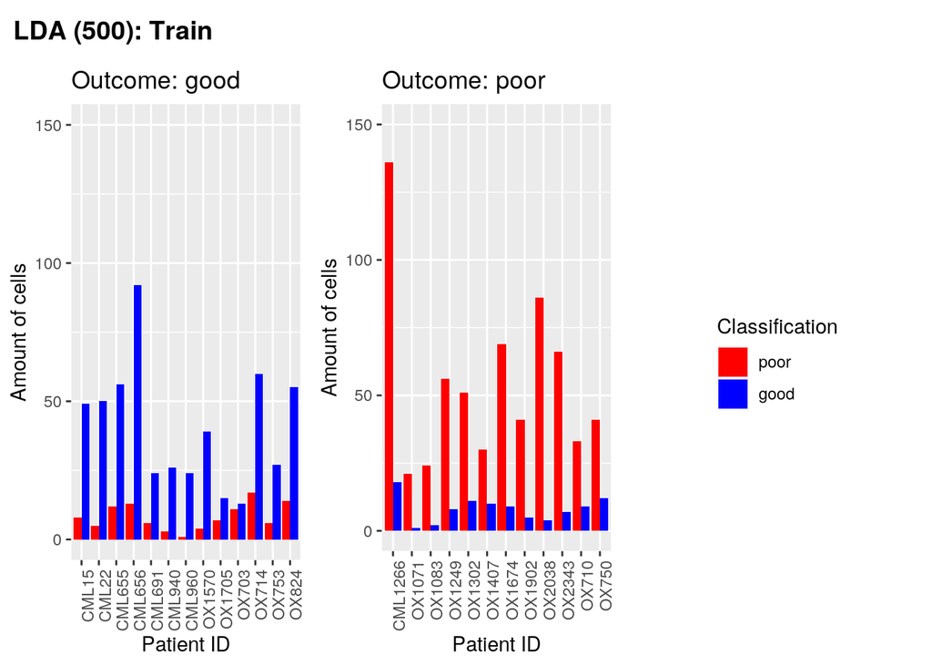

```r
visualize_classes(correct_classified_train_ldamore, glue("LDA ({size_important_genes}): Train"))
```

###### 1.5.4.1.1.2 Test set

Here we can see how the ldamore actually performs, and it does that very poorly.

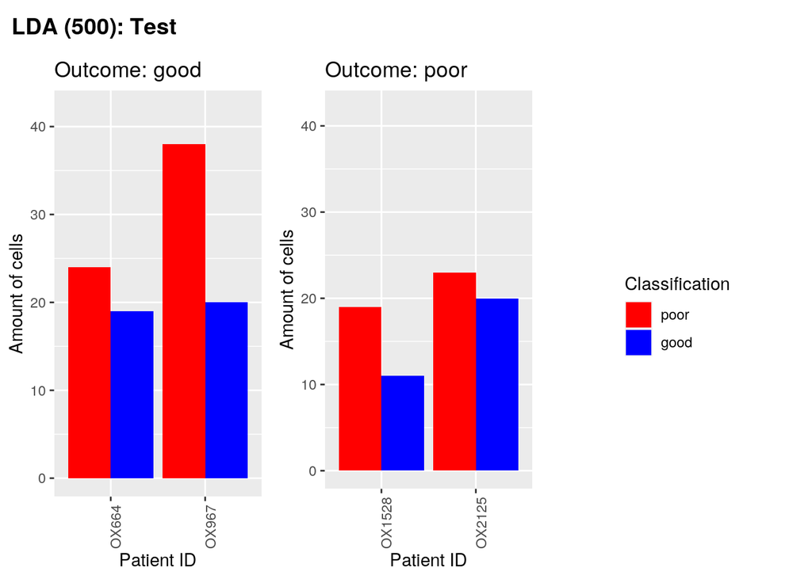

```r
visualize_classes(correct_classified_test_ldamore, glue("LDA ({size_important_genes}): Test"))
```

### 1.5.5 QDA

Instead of linear, we can also attempt quadratic.

**NB:** QDA can be picky, but it should work with the reduced amount of genes and the set seed.

```r
gene_data_qda <- qda(Responder_to_mostimportantgenes, data = gene_data_train)
```

#### 1.5.5.1 Verify

Work on train set

```r
gene_data_train$Responder_status_qda <- predict(gene_data_qda)$class
```

```r
correct_classified_train_qda <- select_correct(gene_data_train, Responder_status_qda)
correct_classified_train_qda
```

| Patient_id | Responder_status | cells | correct |
| --- | --- | --- | --- |
| CML1266 | poor | 154 | 154 |
| CML15 | good | 57 | 57 |
| CML22 | good | 55 | 55 |
| CML655 | good | 68 | 68 |
| CML656 | good | 105 | 105 |
| CML691 | good | 30 | 30 |
| CML940 | good | 29 | 29 |
| CML960 | good | 25 | 25 |
| OX1071 | poor | 22 | 22 |
| OX1083 | poor | 26 | 26 |

[output cut: 15 more lines]

Work on test set

```r
gene_data_test$Responder_status_qda <- predict(gene_data_qda, newdata = gene_data_test)$class
```

```r
correct_classified_test_qda <- select_correct(gene_data_test, Responder_status_qda)
correct_classified_test_qda
```

| Patient_id | Responder_status | cells | correct |
| --- | --- | --- | --- |
| OX1528 | poor | 30 | 27 |
| OX2125 | poor | 43 | 42 |
| OX664 | good | 43 | 4 |
| OX967 | good | 58 | 4 |

##### 1.5.5.1.1 Visualize

###### 1.5.5.1.1.1 Train set

It is expected that the train set would perform reasonably well here.

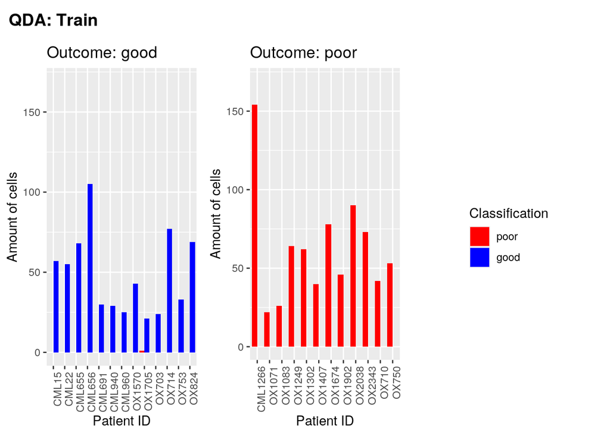

```r
visualize_classes(correct_classified_train_qda, "QDA: Train")
```

###### 1.5.5.1.1.2 Test set

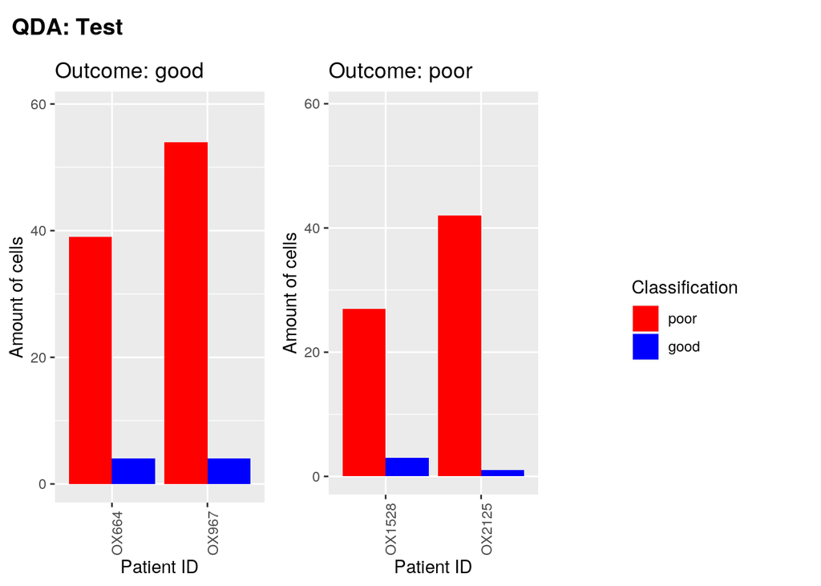

```r
visualize_classes(correct_classified_test_qda, "QDA: Test")
```

### 1.5.6 SVM

```r
gene_data_svm <- svm(Responder_to_mostimportantgenes, data = gene_data_train)
```

#### 1.5.6.1 Verify

Work on train set

```r
gene_data_train$Responder_status_svm <- predict(gene_data_svm)
```

```r
correct_classified_train_svm <- select_correct(gene_data_train, Responder_status_svm)
correct_classified_train_svm
```

| Patient_id | Responder_status | cells | correct |
| --- | --- | --- | --- |
| CML1266 | poor | 154 | 148 |
| CML15 | good | 57 | 54 |
| CML22 | good | 55 | 53 |
| CML655 | good | 68 | 64 |
| CML656 | good | 105 | 101 |
| CML691 | good | 30 | 29 |
| CML940 | good | 29 | 29 |
| CML960 | good | 25 | 25 |
| OX1071 | poor | 22 | 22 |
| OX1083 | poor | 26 | 26 |

[output cut: 15 more lines]

Work on test set

```r
gene_data_test$Responder_status_svm <- predict(gene_data_svm, newdata = gene_data_test)
```

```r
correct_classified_test_svm <- select_correct(gene_data_test, Responder_status_svm)
correct_classified_test_svm
```

| Patient_id | Responder_status | cells | correct |
| --- | --- | --- | --- |
| OX1528 | poor | 30 | 24 |
| OX2125 | poor | 43 | 32 |
| OX664 | good | 43 | 14 |
| OX967 | good | 58 | 16 |

##### 1.5.6.1.1 Visualize

###### 1.5.6.1.1.1 Train set

SVM is famous for its excellent performance. We can see that it performs indeed very well.

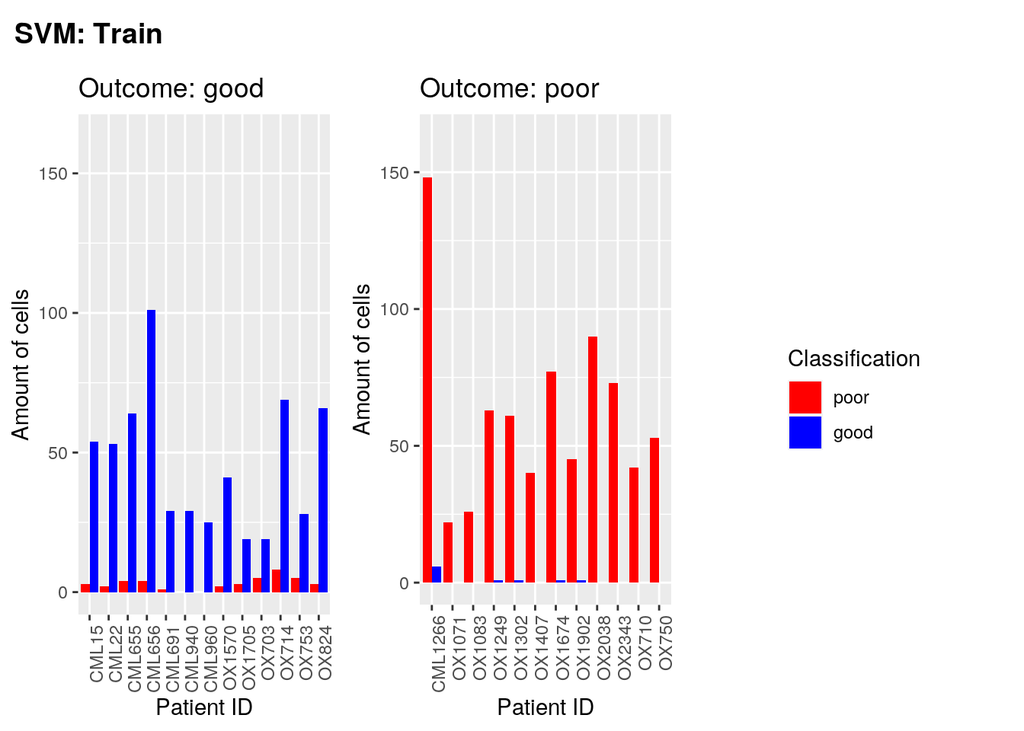

```r
visualize_classes(correct_classified_train_svm, "SVM: Train")
```

###### 1.5.6.1.1.2 Test set

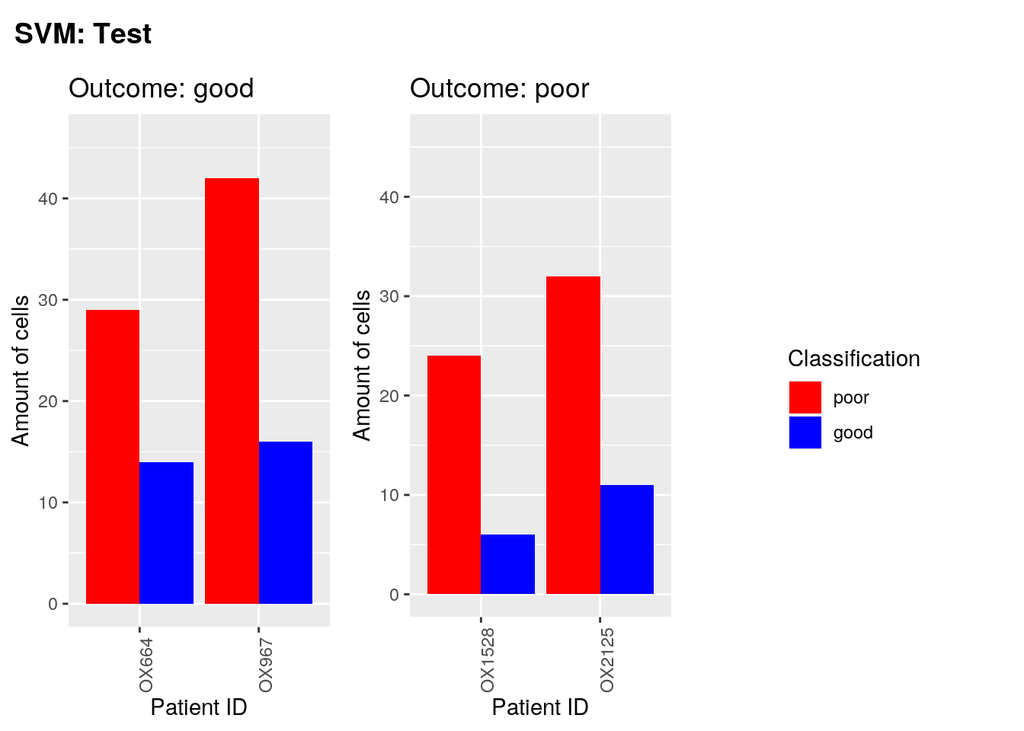

```r
visualize_classes(correct_classified_test_svm, "SVM: Test")
```

### 1.5.7 Introducing regularization

A way to improve on the classification is to introduce regularization. In essence with regularization you penalize the complexity of your model. As in general, less complex model are often more general models.

Here, we will be using glmnet, which implements the *elasticnet* regularization. The *elasticnet* regalarization is a mixed model of rigde and lasso regularization. When using *elasticnet*, one can change the paramater α. If this paramater α is equal to 1, this is in essence the lasso model. If this parameter α is instead equal to 0, this is the ridge model.

With *glmnet* we can also quite easy use the logistics regression needed for this binary classification by using the `family = "binomial"` option.

### 1.5.8 LASSO

```r
x <- model.matrix(Responder_to_allgenes, gene_data_train)[,-1]
y <- ifelse(gene_data_train$Responder_status == "good", 1, 0)

x_test <- model.matrix(Responder_to_allgenes, gene_data_test)[,-1]
```

Another parameter in this model that can be configured is the λ parameter. *glmnet* provides with an easy way to find the best λ parameter using cross validation.

```r
cv_lasso <- cv.glmnet(x, y, alpha = 1, family = "binomial")
gene_data_lasso <- glmnet(x, y, alpha = 1, family = "binomial", lambda = cv_lasso$lambda.min)
```

#### 1.5.8.1 Verify

LASSO works slightly different from the previous classifiers as here we actually have probabilities instead of the classes. TODO: There might be a better idea to diagnose the patient combining the probabilities. Maybe just taking the mean and than take that number instead as the diagnosis.

```r
gene_data_train$prob_train_lasso <- predict(gene_data_lasso, newx = x, type = "response")
gene_data_train$Responder_status_lasso <- ifelse(gene_data_train$prob_train_lasso >= .5, "good", "poor")
```

```r
correct_classified_train_lasso <- select_correct(gene_data_train, Responder_status_lasso)
correct_classified_train_lasso
```

| Patient_id | Responder_status | cells | correct |
| --- | --- | --- | --- |
| CML1266 | poor | 154 | 139 |
| CML15 | good | 57 | 38 |
| CML22 | good | 55 | 40 |
| CML655 | good | 68 | 48 |
| CML656 | good | 105 | 85 |
| CML691 | good | 30 | 15 |
| CML940 | good | 29 | 26 |
| CML960 | good | 25 | 23 |
| OX1071 | poor | 22 | 20 |
| OX1083 | poor | 26 | 24 |

[output cut: 15 more lines]

Work on test set

```r
gene_data_test$prob_test_lasso <- predict(gene_data_lasso, newx = x_test, type = "response")
gene_data_test$Responder_status_lasso <- ifelse(gene_data_test$prob_test_lasso >= .5, "good", "poor")
```

```r
correct_classified_test_lasso <- select_correct(gene_data_test, Responder_status_lasso)
correct_classified_test_lasso
```

| Patient_id | Responder_status | cells | correct |
| --- | --- | --- | --- |
| OX1528 | poor | 30 | 23 |
| OX2125 | poor | 43 | 32 |
| OX664 | good | 43 | 12 |
| OX967 | good | 58 | 20 |

##### 1.5.8.1.1 Visualize

###### 1.5.8.1.1.1 Train set

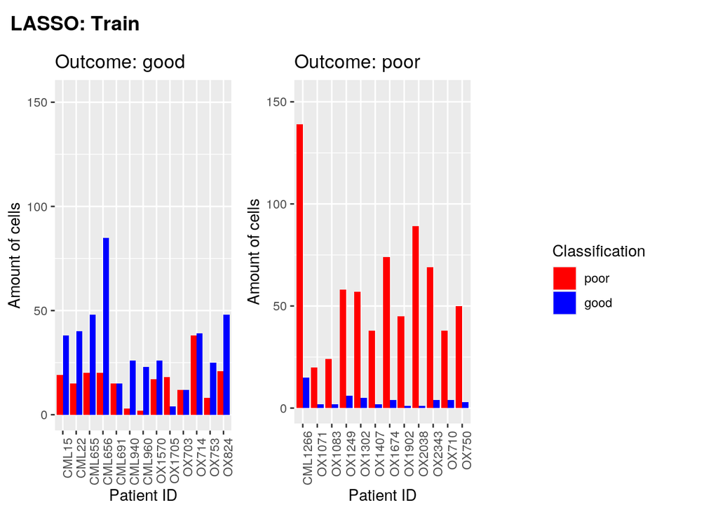

```r
visualize_classes(correct_classified_train_lasso, "LASSO: Train")
```

###### 1.5.8.1.1.2 Test set

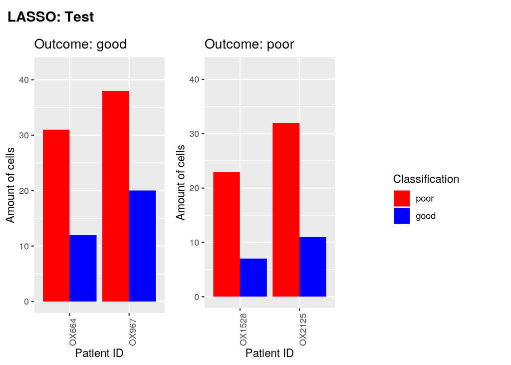

```r
visualize_classes(correct_classified_test_lasso, "LASSO: Test")
```

### 1.5.9 Ridge

```r
cv_ridge <- cv.glmnet(x, y, alpha = 0, family = "binomial")
gene_data_ridge <- glmnet(x, y, alpha = 0, family = "binomial", lambda = cv_ridge$lambda.min)
```

#### 1.5.9.1 Verify

```r
gene_data_train$prob_train_ridge <- predict(gene_data_ridge, newx = x, type = "response")
gene_data_train$Responder_status_ridge <- ifelse(gene_data_train$prob_train_ridge >= .5, "good", "poor")
```

```r
correct_classified_train_ridge <- select_correct(gene_data_train, Responder_status_ridge)
correct_classified_train_ridge
```

| Patient_id | Responder_status | cells | correct |
| --- | --- | --- | --- |
| CML1266 | poor | 154 | 145 |
| CML15 | good | 57 | 56 |
| CML22 | good | 55 | 52 |
| CML655 | good | 68 | 53 |
| CML656 | good | 105 | 88 |
| CML691 | good | 30 | 26 |
| CML940 | good | 29 | 28 |
| CML960 | good | 25 | 22 |
| OX1071 | poor | 22 | 22 |
| OX1083 | poor | 26 | 26 |

[output cut: 15 more lines]

Work on test set

```r
gene_data_test$prob_test_ridge <- predict(gene_data_ridge, newx = x_test, type = "response")
gene_data_test$Responder_status_ridge <- ifelse(gene_data_test$prob_test_ridge >= .5, "good", "poor")
```

```r
correct_classified_test_ridge <- select_correct(gene_data_test, Responder_status_ridge)
correct_classified_test_ridge
```

| Patient_id | Responder_status | cells | correct |
| --- | --- | --- | --- |
| OX1528 | poor | 30 | 26 |
| OX2125 | poor | 43 | 39 |
| OX664 | good | 43 | 3 |
| OX967 | good | 58 | 9 |

##### 1.5.9.1.1 Visualize

###### 1.5.9.1.1.1 Train set

RIDGE is famous for its excellent performance. We can see that it performs indeed very well.

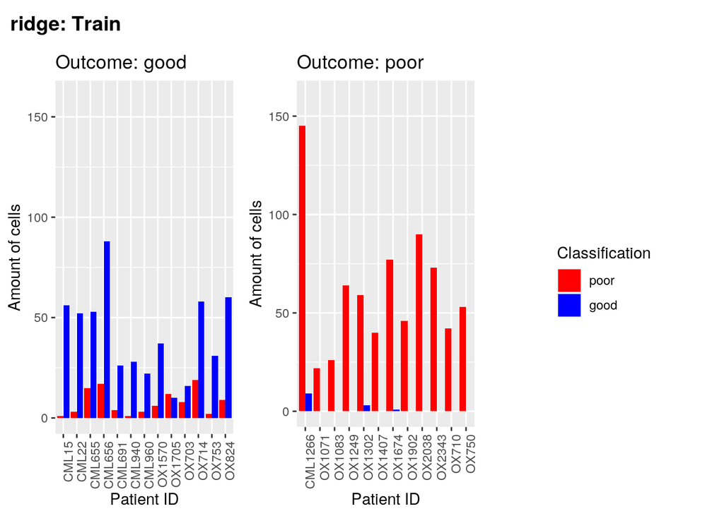

```r
visualize_classes(correct_classified_train_ridge, "ridge: Train")
```

###### 1.5.9.1.1.2 Test set

Here we can see how the ridge actually performs, and it does not reasonably well, only for ‘poor’ outcome patients it does work.

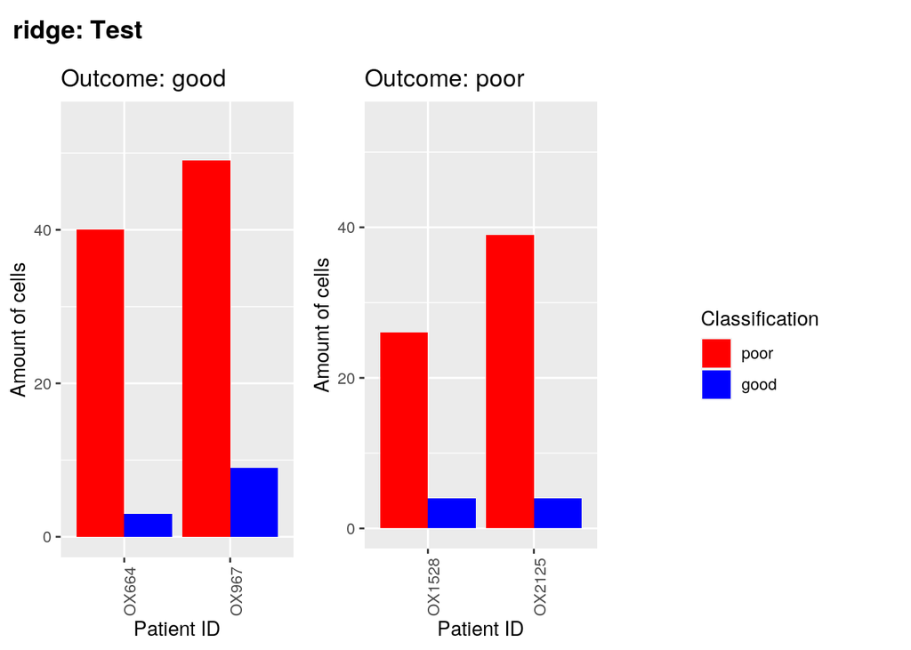

```r
visualize_classes(correct_classified_test_ridge, "ridge: Test")
```